# Домашнее задание № 1

## Работа с данными.

По адресу http://people.math.umass.edu/~anna/Stat597AFall2016/rnf6080.dat можно получить набор данных об осадках в Канаде с 1960 по 1980 годы. Необходимо загрузить эти данные при помощи `read.table`. Воспользуйтесь справкой, чтобы изучить аргументы, которые принимает функция. - Загрузите данные в датафрейм, который назовите `data.df`.

```r
data.df<-read.table("http://people.math.umass.edu/~anna/Stat597AFall2016/rnf6080.dat")
```

- Сколько строк и столбцов в `data.df`? Если получилось не 5070 наблюдений 27 переменных, то проверяйте аргументы.

```r
#Количество строк:
data.df.nrow<-nrow(data.df)
#Количество столбцов:
data.df.ncol<-ncol(data.df)
#Количество строк:
data.df.nrow
```

```
## [1] 5070
```

```r
#Количество столбцов:
data.df.ncol
```

```
## [1] 27
```

- Получите имена колонок из `data.df`.

```r
data.df.names<-names(data.df)
```

```r
variable<-data.df[7,5]
variable
```

```
## [1] 0
```

- Напечатайте целиком 2 строку из `data.df`

```r
data.df[2,]
```

```
##   V1 V2 V3 V4 V5 V6 V7 V8 V9 V10 V11 V12 V13 V14 V15 V16 V17 V18 V19 V20
## 2 60  4  2  0  0  0  0  0  0   0   0   0   0   0   0   0   0   0   0   0
##   V21 V22 V23 V24 V25 V26 V27
## 2   0   0   0   0   0   0   0
```

- Объясните, что делает следующая строка кода `names(data.df) <- c("year", "month", "day", seq(0,23))`. Воспользуйтесь функциями `head` и `tail`, чтобы просмотреть таблицу. Что представляют собой последние 24 колонки?

```r
#Следующая строка кода, присвоит имена колонкам в датафрейме
#(первым трем year, month, day соответственно, остальным номера от 0 до 23)
names(data.df) <- c("year", "month", "day", seq(0,23))
#Вызов ф-ии head - которая выводит имена колонок и несколько первых значений
head(data.df)
```

```
##   year month day 0 1 2 3 4 5 6 7 8 9 10 11 12 13 14 15 16 17 18 19 20 21
## 1   60     4   1 0 0 0 0 0 0 0 0 0 0  0  0  0  0  0  0  0  0  0  0  0  0
## 2   60     4   2 0 0 0 0 0 0 0 0 0 0  0  0  0  0  0  0  0  0  0  0  0  0
## 3   60     4   3 0 0 0 0 0 0 0 0 0 0  0  0  0  0  0  0  0  0  0  0  0  0
## 4   60     4   4 0 0 0 0 0 0 0 0 0 0  0  0  0  0  0  0  0  0  0  0  0  0
## 5   60     4   5 0 0 0 0 0 0 0 0 0 0  0  0  0  0  0  0  0  0  0  0  0  0
## 6   60     4   6 0 0 0 0 0 0 0 0 0 0  0  0  0  0  0  0  0  0  0  0  0  0
##   22 23
## 1  0  0
## 2  0  0
## 3  0  0
## 4  0  0
## 5  0  0
## 6  0  0
```

```r
#Вызов ф-ии tail - которая выводит заголовки и последние несколько записей
tail(data.df)
```

```
##      year month day 0 1 2 3 4 5 6 7 8 9 10 11 12 13 14 15 16 17 18 19 20
## 5065   80    11  25 0 0 0 0 0 0 0 0 0 0  0  0  0  0  0  0  0  0  0  0  0
## 5066   80    11  26 0 0 0 0 0 0 0 0 0 0  0  0  0  0  0  0  0  0  0  0  0
## 5067   80    11  27 0 0 0 0 0 0 0 0 0 0  0  0  0  0  0  0  0  0  0  0  0
## 5068   80    11  28 0 0 0 0 0 0 0 0 0 0  0  0  0  0  0  0  0  0  0  0  0
## 5069   80    11  29 0 0 0 0 0 0 0 0 0 0  0  0  0  0  0  0  0  0  0  0  0
## 5070   80    11  30 0 0 0 0 0 0 0 0 0 0  0  0  0  0  0  0  0  0  0  0  0
##      21 22 23
## 5065  0  0  0
## 5066  0  0  0
## 5067  0  0  0
## 5068  0  0  0
## 5069  0  0  0
## 5070  0  0  0
```

- Добавьте новую колонку с названием *daily*, в которую запишите сумму крайних правых 24 колонок. Постройте гистограмму по этой колонке. Какие выводы можно сделать?

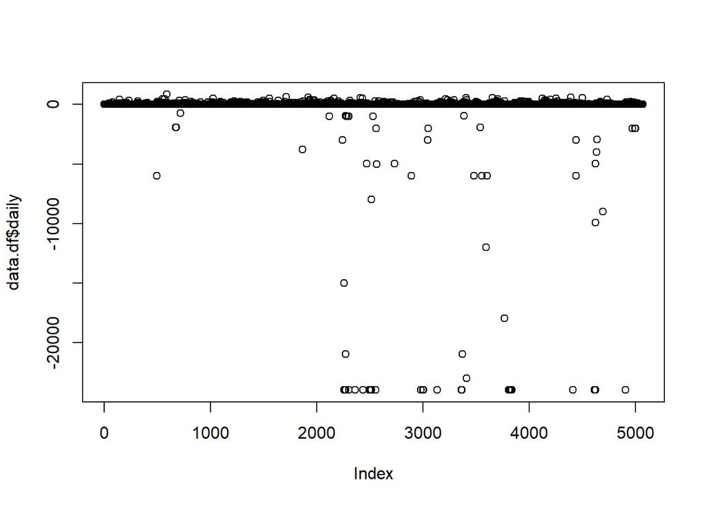

```r
for(i in seq(1,nrow(data.df))){
      data.df[i,28]<-sum(data.df[i,4:27])
   }
names(data.df)<-c("year", "month", "day", seq(0,23),"daily")
plot(data.df$daily)
```

- Создайте новый датафрейм `fixed.df` в котром исправьте замеченную ошибку. Постройте новую гистограмму, поясните почему она более корректна.

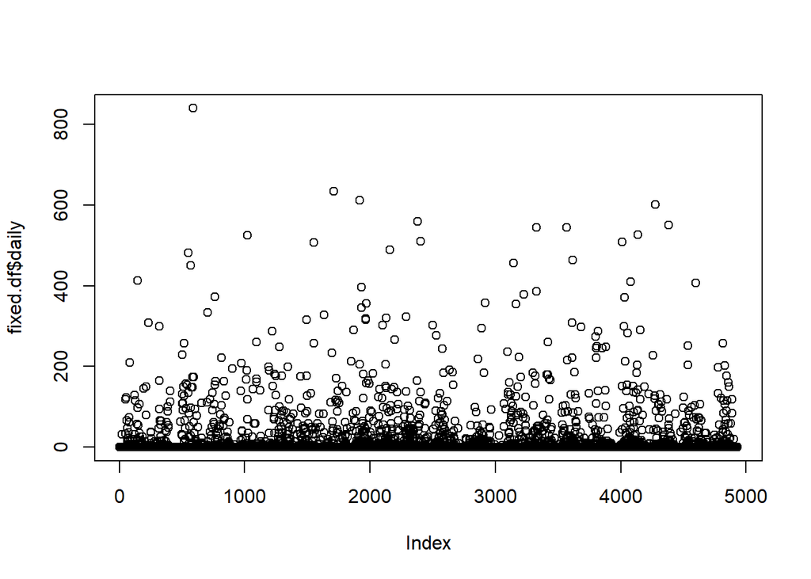

```r
fixed.df<-data.df[data.df$daily>=0,]
plot(fixed.df$daily)
```

## Синтаксис и типизирование

- Для каждой строки кода поясните полученный результат, либо объясните почему она ошибочна.

```r
#Данные функции работают, не так как ожидалось, потому что они применяются не к списку числовых значений, а
#к списку строк
v <- c("4", "8", "15", "16", "23", "42")
max(v)
```

```
## [1] "8"
```

```r
#Функция max для строк определила максимальное значение строки исходя из лексиграфического порядка
#Соответственно, т.к. цифра "8" является самой большой цифрой, с которой начинаются строки, то она
#и является максимальной
sort(v)
```

```
## [1] "15" "16" "23" "4"  "42" "8"
```

```r
#Функция сортировки также как и ф-ия "max" сравнивает строки исходя из лексиграфического порядка,
#а при равном исходя из длины строки
###sum(v)     !!!!!Ошибка
#Предсказуемо, что ф-ия "sum" не работает, и ясно из ошибки, данная ф-ия не может складывать типы
#данных такие, как character
```

- Для следующих наборов команд поясните полученный результат, либо объясните почему они ошибочна.

```r
v2 <- c("5",7,12)
#v2[2] + 2[3]   !!!!!Ошибка
#В данном случае операция получение по индексу не может быть применена к типу данных numeric

df3 <- data.frame(z1="5",z2=7,z3=12)
df3[1,2] + df3[1,3]
```

```
## [1] 19
```

```r
#В данном случае ошибки не происходит, потому что вначале создается dataframe, в который записывается
#строка и два числа, а затем производится сложение двух чисел, при сложении df3[1,1] с любым из двух
#других элементов, получалась бы ошибка, т.к. типы складываемых переменных не совпадают и не могут быть сложены
l4 <- list(z1="6", z2=42, z3="49", z4=126)
l4[[2]] + l4[[4]]
```

```
## [1] 168
```

```r
#l4[2] + l4[4]    !!!!!Ошибка
#В данном примере в первом случае нет ошибки, потому что при обращении через двойные скобки возвращается
#элемент списка, а через одинарные-список с одним элементом, поэтому во втором случае происходит ошибка
```

## Работа с функциями и операторами

- Оператор двоеточие создаёт последовательность целых чисел по порядку. Этот оператор — частный случай функции `seq()`, которую вы использовали раньше. Изучите эту функцию, вызвав команду `?seq`. Испольуя полученные знания выведите на экран:
  1. Числа от 1 до 10000 с инкрементом 372.
  2. Числа от 1 до 10000 длиной 50.

```r
#1)
seq(from=1,to=10000,by=372)
```

```
##  [1]    1  373  745 1117 1489 1861 2233 2605 2977 3349 3721 4093 4465 4837
## [15] 5209 5581 5953 6325 6697 7069 7441 7813 8185 8557 8929 9301 9673
```

```r
#2)
seq(from=1,to=10000,length.out = 50)
```

```
##  [1]     1.0000   205.0612   409.1224   613.1837   817.2449  1021.3061
##  [7]  1225.3673  1429.4286  1633.4898  1837.5510  2041.6122  2245.6735
## [13]  2449.7347  2653.7959  2857.8571  3061.9184  3265.9796  3470.0408
## [19]  3674.1020  3878.1633  4082.2245  4286.2857  4490.3469  4694.4082
## [25]  4898.4694  5102.5306  5306.5918  5510.6531  5714.7143  5918.7755
## [31]  6122.8367  6326.8980  6530.9592  6735.0204  6939.0816  7143.1429
## [37]  7347.2041  7551.2653  7755.3265  7959.3878  8163.4490  8367.5102
## [43]  8571.5714  8775.6327  8979.6939  9183.7551  9387.8163  9591.8776
## [49]  9795.9388 10000.0000
```

- Функция `rep()` повторяет переданный вектор указанное число раз. Объясните разницу между `rep(1:5,times=3)` и `rep(1:5, each=3)`.

```r
rep(1:5,times=3)
```

```
##  [1] 1 2 3 4 5 1 2 3 4 5 1 2 3 4 5
```

```r
rep(1:5, each=3)
```

```
##  [1] 1 1 1 2 2 2 3 3 3 4 4 4 5 5 5
```

Разница между двумя аргументами, передаваемыми в ф-ию `rep()`, аргумент `times` повторяет переданный вектор, указанное число раз, а аргумент `each` повторяет каждый элемент передаваемого вектора указанное число раз.

# Требования к оформлению

Работа должна быть выполнена на языке R Markdown в среде RStudio и сохранена в свой репозиторий в папку hw01. Также требуется сохранить результат в виде PDF и отправить почтой для проверки. Справку по установке и настройке R Markdown можно найти здесь http://rmarkdown.rstudio.com/